# PROYECTO

### Análisis por clusters

- Ahora queremos encontrar patrones o grupos (clusters) dentro del conjunto.

```r
# Recordemos los datos obtenidos al analizar varianzas y correlaciones
summary(numDC)
```

```
##      Height          Weight       Intelligence       Strength
##  Min.   : 61.0   Min.   : 18.0   Min.   :  1.00   Min.   :  1.00
##  1st Qu.:178.0   1st Qu.: 72.0   1st Qu.: 32.00   1st Qu.: 10.00
##  Median :188.0   Median : 92.0   Median : 50.00   Median : 23.00
##  Mean   :183.1   Mean   :106.7   Mean   : 50.19   Mean   : 32.06
##  3rd Qu.:188.0   3rd Qu.:113.0   3rd Qu.: 75.00   3rd Qu.: 48.00
##  Max.   :279.0   Max.   :817.0   Max.   :113.00   Max.   :100.00
##      Speed          Durability         Power            Combat
##  Min.   :  1.00   Min.   :  1.00   Min.   :  0.00   Min.   :  1.00
##  1st Qu.: 12.00   1st Qu.: 11.00   1st Qu.: 19.00   1st Qu.: 30.50
##  Median : 25.00   Median : 40.50   Median : 42.00   Median : 45.00
##  Mean   : 31.15   Mean   : 45.39   Mean   : 45.97   Mean   : 46.71
##  3rd Qu.: 44.50   3rd Qu.: 80.00   3rd Qu.: 72.00   3rd Qu.: 68.75
##  Max.   :100.00   Max.   :120.00   Max.   :100.00   Max.   :100.00
```

```r
dim(numDC)
```

```
## [1] 206   8
```

```r
var(data.matrix(numDC))
```

```
##                 Height     Weight Intelligence  Strength     Speed Durability
## Height       464.70831  670.28743    -10.81785  71.90481 -14.74933   60.45641
## Weight       670.28743 6531.90026    165.01563 790.81118 -10.91106  596.59872
## Intelligence -10.81785  165.01563    965.42553 510.05110 447.69259  646.47937
## Strength      71.90481  790.81118    510.05110 998.06917 509.92704  859.58482
## Speed        -14.74933  -10.91106    447.69259 509.92704 714.23578  624.82347
## Durability    60.45641  596.59872    646.47937 859.58482 624.82347 1244.96171
## Power         53.50585  353.92205    595.03983 689.43599 589.50197  910.20175
## Combat        26.10182  230.98792    704.19735 490.18402 421.13599  609.38634
##                   Power    Combat
## Height         53.50585  26.10182
## Weight        353.92205 230.98792
## Intelligence  595.03983 704.19735
## Strength      689.43599 490.18402
## Speed         589.50197 421.13599
## Durability    910.20175 609.38634
## Power        1102.56500 524.33796
## Combat        524.33796 849.62001
```

```r
cor.mat_all <- cor(data.matrix(numDC), use="complete.obs")
cor.mat_all
```

```
##                   Height       Weight Intelligence  Strength        Speed
## Height        1.00000000  0.384725595  -0.01615071 0.1055814 -0.025601247
## Weight        0.38472560  1.000000000   0.06571219 0.3097225 -0.005051569
## Intelligence -0.01615071  0.065712186   1.00000000 0.5196058  0.539137716
## Strength      0.10558139  0.309722465   0.51960579 1.0000000  0.603958256
## Speed        -0.02560125 -0.005051569   0.53913772 0.6039583  1.000000000
## Durability    0.07948297  0.209211016   0.58968121 0.7711350  0.662610836
## Power         0.07474961  0.131882066   0.57674594 0.6572212  0.664297097
## Combat        0.04154017  0.098052153   0.77753980 0.5323122  0.540616372
##              Durability      Power     Combat
## Height       0.07948297 0.07474961 0.04154017
## Weight       0.20921102 0.13188207 0.09805215
## Intelligence 0.58968121 0.57674594 0.77753980
## Strength     0.77113501 0.65722115 0.53231225
## Speed        0.66261084 0.66429710 0.54061637
## Durability   1.00000000 0.77688649 0.59251909
## Power        0.77688649 1.00000000 0.54174740
## Combat       0.59251909 0.54174740 1.00000000
```

```r
#  Como no queremos que el algoritmo de agrupamiento dependa de una unidad variable arbitraria, comenzamos escalando/estandarizando los datos usando la función R scale:
US_df <- scale(numDC)
head(US_df)
var(US_df)

#  Calculamos los valores de disimilitud con dist y luego usamos hclusty y especificamos el método de aglomeración que se usará (es decir, "completo", "promedio", etc.). Con la tabla comparativa de metodos y el coheficiente de correlación, vemos que el método optimo es average. Entonces podemos trazar el dendograma.

dist <- dist(US_df, method = "euclidean")
```

- Realizamos los clusters

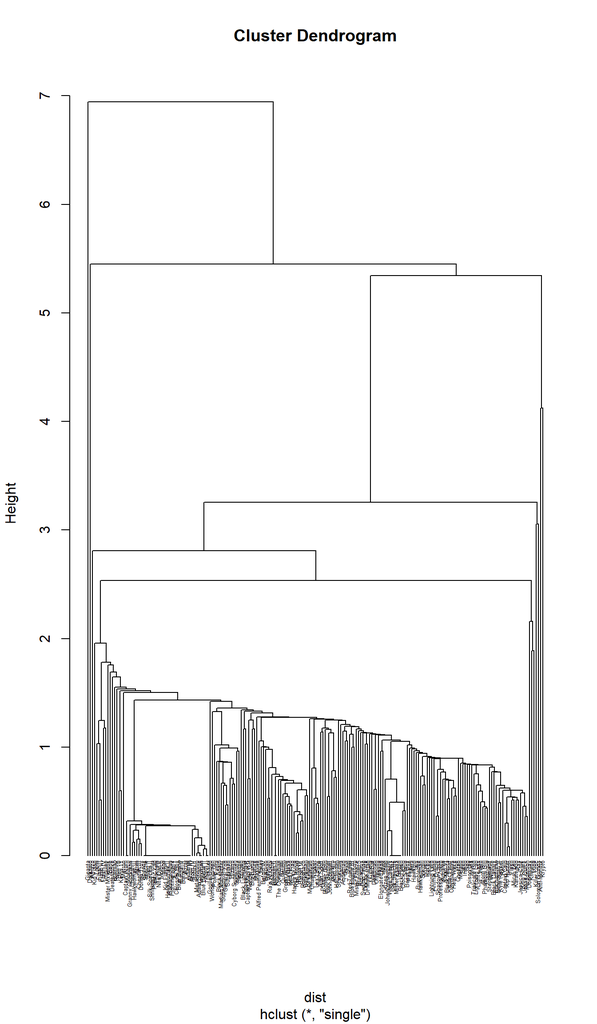

```r
cluster_single <- hclust (d = dist, method = 'single')
plot(cluster_single,cex=0.4, hang = -2)
```

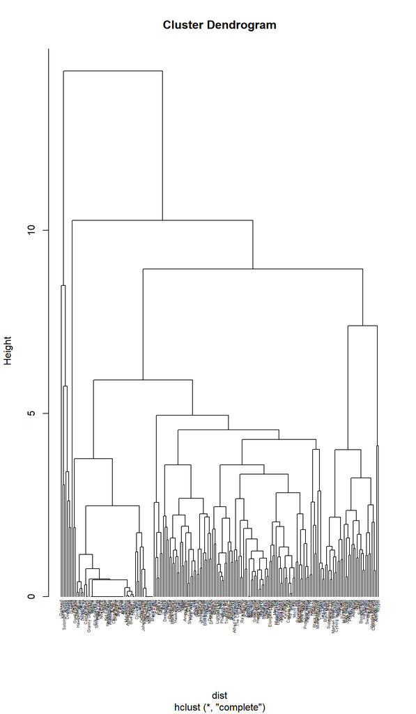

```r
cluster_complete <- hclust (d = dist, method = 'complete')
plot(cluster_complete,cex=0.4, hang = -2)
```

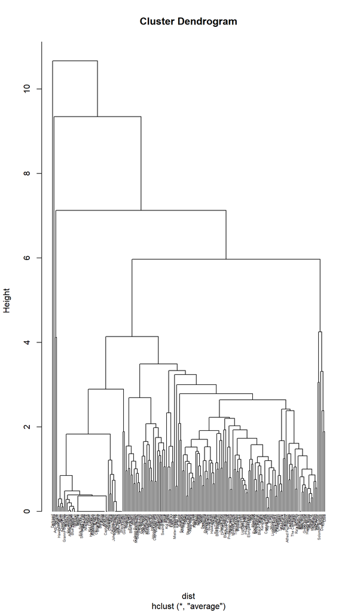

```r
cluster_average <- hclust (d = dist, method = 'average')
plot(cluster_average,cex=0.4, hang = -2)
```

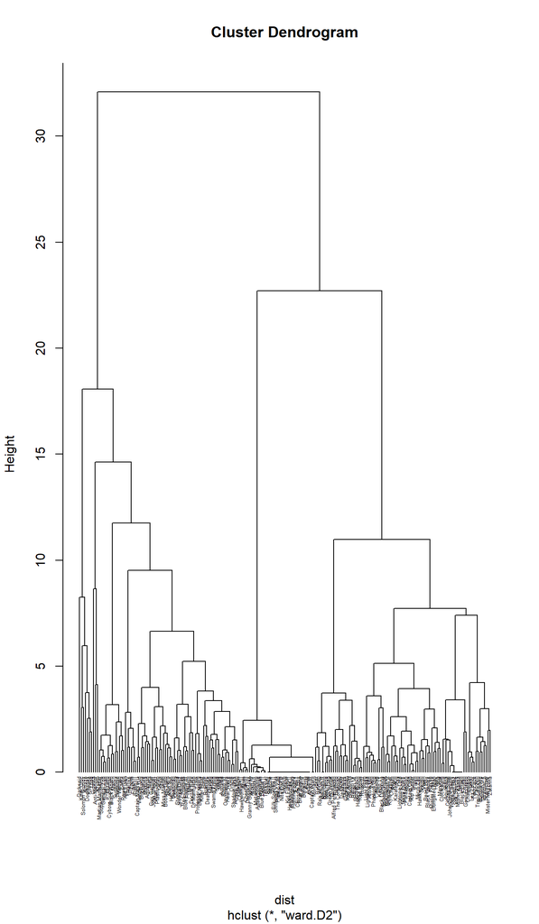

```r
cluster_ward <- hclust (d = dist, method = 'ward.D2')
plot(cluster_ward,cex=0.4, hang = -2)
```

- Comparamos los coheficientes de correlación de los distintos métodos, y obtenemos una tabla comparativa donde se muestra que el método más optimos es “average”

```r
library(NbClust)
library(factoextra)

# Comparar coeficiente de correlación de los métodos

# vector con nombre de los métodos
m <- c( "average", "single", "complete", "ward.D2", "median", "centroid")
names(m) <- c( "average", "single", "complete", "ward.D2", "median", "centroid")

# Función para calcular el coeficiente de correlación
coef_cor <- function(x) {
  cor(x=dist, cophenetic(hclust(d=dist, method = x)))
}

# Tabla comparativa
coef_tabla <- map_dbl(m, coef_cor)
coef_tabla
```

```
##   average    single  complete   ward.D2    median  centroid
## 0.8505797 0.7412916 0.7295439 0.5371533 0.7935697 0.8255001
```

- Ahora vamos a calcular el número óptimo de clusters y realizar el cluster con el método y número óptimos.

```r
# Aplicar todos los índices y métodos
res.nbclust <- NbClust(US_df, distance = "euclidean",
                       min.nc = 3, max.nc = 8,
                       method = "average", index ="all")
```

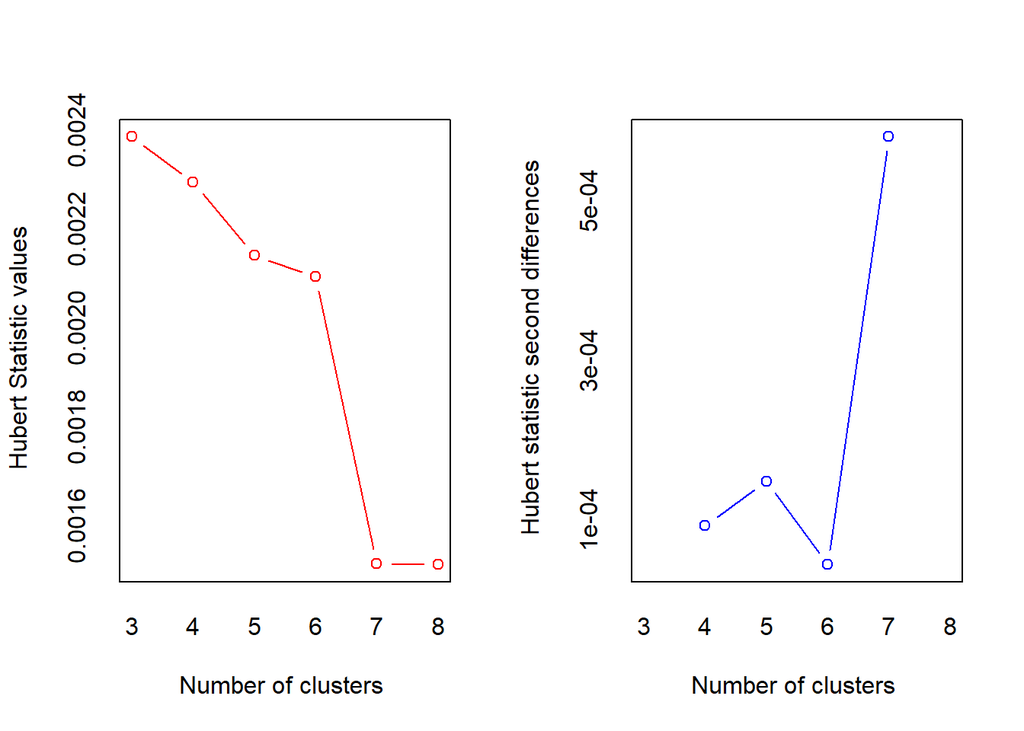

```
## *** : The Hubert index is a graphical method of determining the number of clusters.
##                 In the plot of Hubert index, we seek a significant knee that corresponds to a
##                 significant increase of the value of the measure i.e the significant peak in Hubert
##                 index second differences plot.
##
```

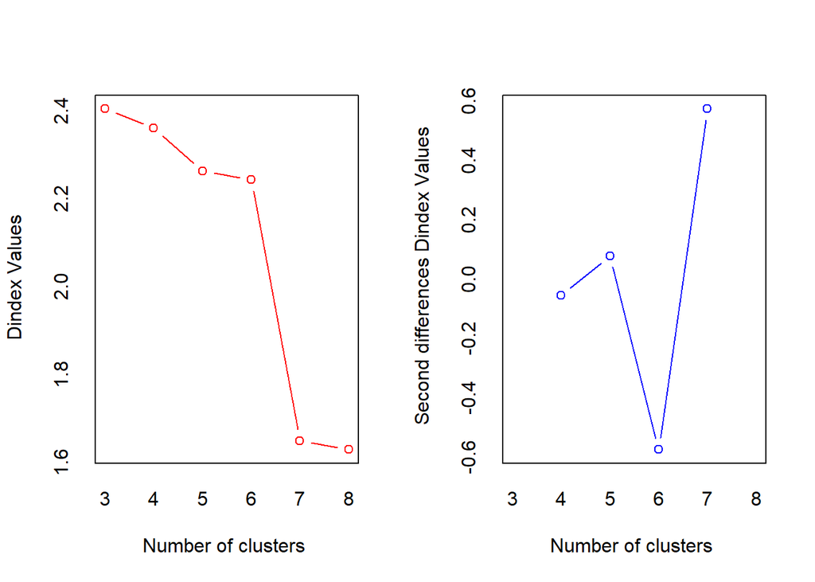

```
## *** : The D index is a graphical method of determining the number of clusters.
##                 In the plot of D index, we seek a significant knee (the significant peak in Dindex
##                 second differences plot) that corresponds to a significant increase of the value of
##                 the measure.
##
## * Among all indices:
## * 8 proposed 3 as the best number of clusters
## * 2 proposed 4 as the best number of clusters
## * 2 proposed 5 as the best number of clusters
## * 1 proposed 6 as the best number of clusters
## * 10 proposed 7 as the best number of clusters
## * 1 proposed 8 as the best number of clusters
##
##                    ***** Conclusion *****
##
## * According to the majority rule, the best number of clusters is  7
##
##
```

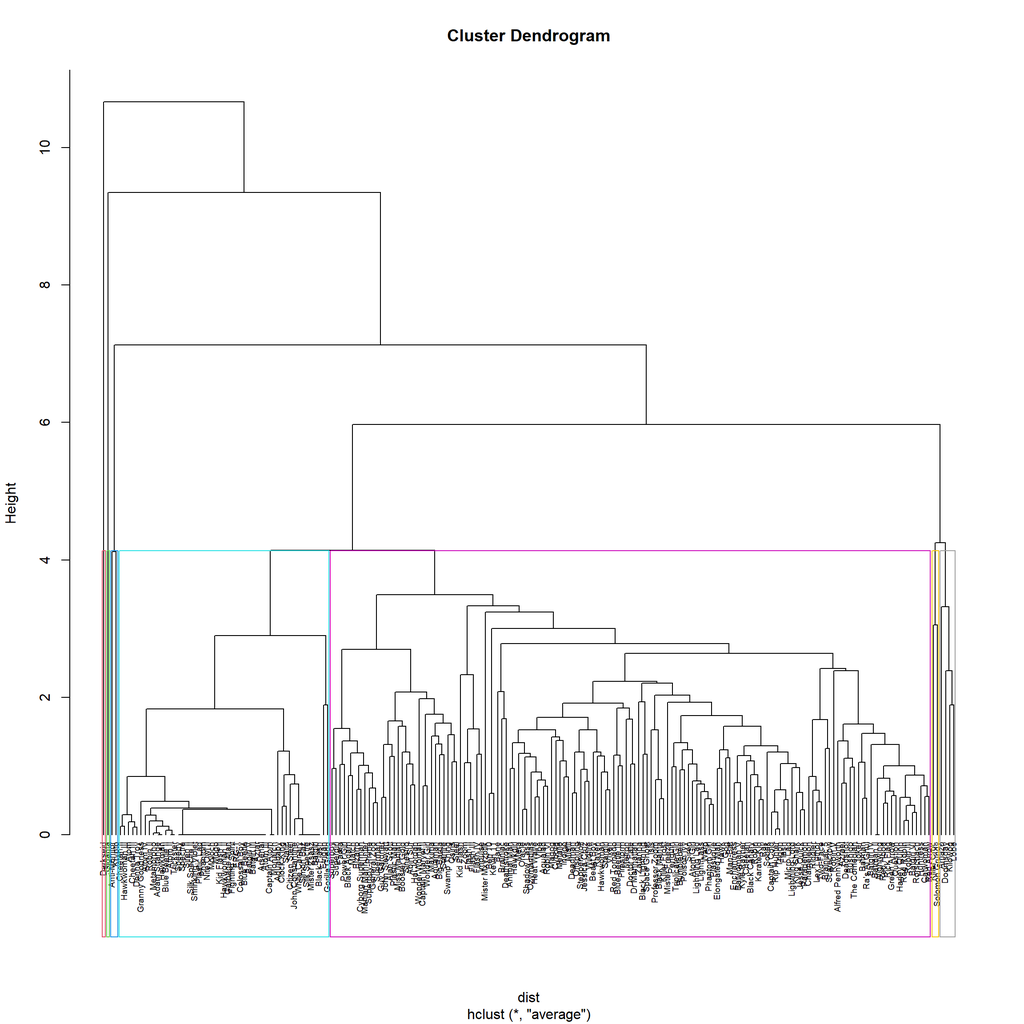

```r
# Realizar plot con el número óptimo de cluster y marcar los grupos
plot(cluster_average, cex = 0.6, hang = -2)
rect.hclust(cluster_average, k = 7, border = 2:8)
```

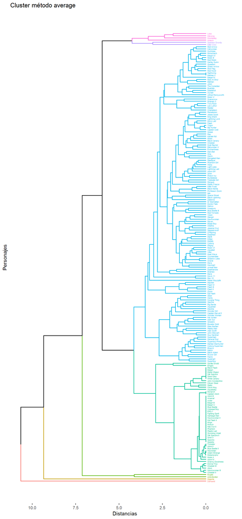

```r
# Clusters
set.seed(12345)

hc_average <- hclust(d=dist, method = "average")
hc_complete <- hclust(d=dist, method = "complete")
hc_single <- hclust(d=dist, method = "single")
hc_centroid <- hclust(d=dist, method = "centroid")



fviz_dend(x = hc_average, k=7,
          cex = 0.3,
          main = "Cluster método average",
          xlab = "Personajes",
          ylab = "Distancias",
          type= "rectangle",
          sub = "",
          horiz = TRUE)
```

```r
sub_grp <- cutree(hc_average, k = 7)
table(sub_grp)
```

```
## sub_grp
##   1   2   3   4   5   6   7
## 145  51   4   2   1   1   2
```

[figure not shown]

```r
fviz_cluster(list(data = US_df, cluster = sub_grp))
```

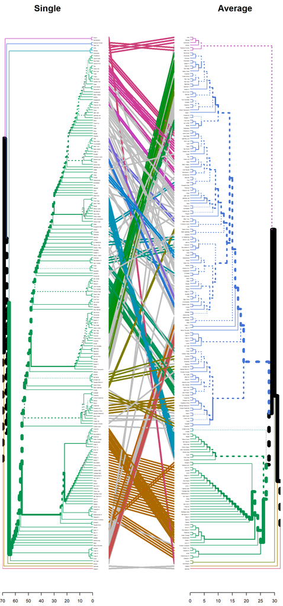

```r
# Comparar dendrogramas
library(dendextend)

hc_single <- as.dendrogram(hc_single)
hc_average <- as.dendrogram(hc_average)

tanglegram(rank_branches(hc_single),rank_branches(hc_average),
           main_left = "Single",
           main_right = "Average", lab.cex= 0.3, margin_inner = 3, k_branches = 7)
```

### Análisis de PCA

```r
library(psych)
kmo.1 <-KMO(numDC)
kmo.1
```

```
## Kaiser-Meyer-Olkin factor adequacy
## Call: KMO(r = numDC)
## Overall MSA =  0.84
## MSA for each item =
##       Height       Weight Intelligence     Strength        Speed   Durability
##         0.55         0.56         0.81         0.87         0.91         0.85
##        Power       Combat
##         0.88         0.81
```

- Calculamos los componentes principales con la función princomp.
  - Con la instrucción loadings lo que obtenemos son las cargas de los componentes principales. Es decir, lo que obtenemos son los coeficientes que se usarán en las combinaciones lineales para calcular cada componente principal. Por ejemplo, para un conjunto de datos x1,x2,…,xp la primera columna que está denotada por Comp.1 tiene los coeficientes  
    a11,a21,…,ap1 de la combinación lineal con la que se obtiene la primera componente principal:Z1=a11x1+a21x2+…ap1xp.

```r
cp1 <- princomp(numDC, cor = TRUE)
summary(cp1)
```

```
## Importance of components:
##                           Comp.1    Comp.2     Comp.3     Comp.4     Comp.5
## Standard deviation     2.0406306 1.1900332 0.84948440 0.79738814 0.58920608
## Proportion of Variance 0.5205217 0.1770224 0.09020297 0.07947848 0.04339548
## Cumulative Proportion  0.5205217 0.6975440 0.78774699 0.86722547 0.91062095
##                            Comp.6     Comp.7     Comp.8
## Standard deviation     0.56226422 0.46600294 0.42630110
## Proportion of Variance 0.03951763 0.02714484 0.02271658
## Cumulative Proportion  0.95013858 0.97728342 1.00000000
```

- Esta primera componente principal será la que refleje la mayor variabilidad de los datos. Las cargas son las entradas de cada eigenvector son las siguientes:

```r
cp1$loadings
```

```
##
## Loadings:
##              Comp.1 Comp.2 Comp.3 Comp.4 Comp.5 Comp.6 Comp.7 Comp.8
## Height               0.672  0.302  0.665
## Weight        0.112  0.682        -0.612 -0.258 -0.271
## Intelligence  0.388 -0.154  0.538 -0.165        -0.139  0.676  0.165
## Strength      0.409  0.130 -0.318 -0.127  0.140  0.689  0.237 -0.384
## Speed         0.389 -0.174 -0.231  0.286 -0.820
## Durability    0.437        -0.258         0.318        -0.238  0.760
## Power         0.417        -0.249  0.197  0.360 -0.626        -0.448
## Combat        0.388 -0.101  0.574 -0.140         0.152 -0.648 -0.203
##
##                Comp.1 Comp.2 Comp.3 Comp.4 Comp.5 Comp.6 Comp.7 Comp.8
## SS loadings     1.000  1.000  1.000  1.000  1.000  1.000  1.000  1.000
## Proportion Var  0.125  0.125  0.125  0.125  0.125  0.125  0.125  0.125
## Cumulative Var  0.125  0.250  0.375  0.500  0.625  0.750  0.875  1.000
```

- Las desviaciones estándar son las raíces de las lambdas.

```r
cp1$sdev
```

```
##    Comp.1    Comp.2    Comp.3    Comp.4    Comp.5    Comp.6    Comp.7    Comp.8
## 2.0406306 1.1900332 0.8494844 0.7973881 0.5892061 0.5622642 0.4660029 0.4263011
```

- Para calcular la varianza debemos elevar al cuadrado cada una de las entradas.

```r
varianza.cp1 <- (cp1$sdev)^2
varianza.cp1
```

```
##    Comp.1    Comp.2    Comp.3    Comp.4    Comp.5    Comp.6    Comp.7    Comp.8
## 4.1641732 1.4161789 0.7216237 0.6358279 0.3471638 0.3161411 0.2171587 0.1817326
```

- Una forma de ver con cuantos componentes nos conviene trabajar es con el gráfico de codo.

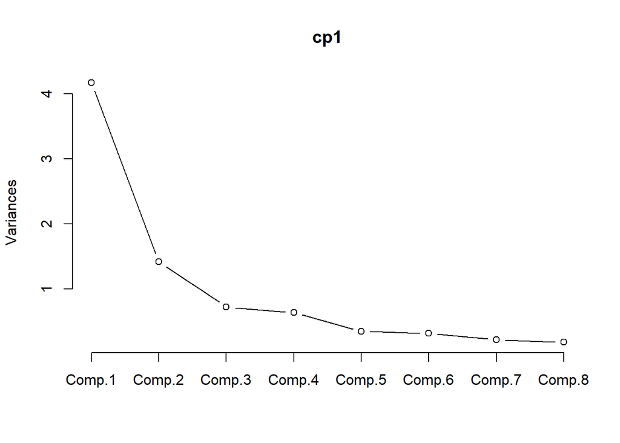

```r
screeplot(cp1, type="lines")
```

```r
res.pca <- prcomp(numDC, scale = TRUE )
```

- Vamos a graficar a los personajes y corolearlos por perfiles similares.

[figure not shown]

```r
fviz_pca_ind(res.pca,
             col.ind = "cos2", # color por la calidad de representación
             gradient.cols = c("#00AFBB", "#E7B800", "#FC4E07"),
             repel = TRUE     # evitar que se sobrelape el texto
             )
```

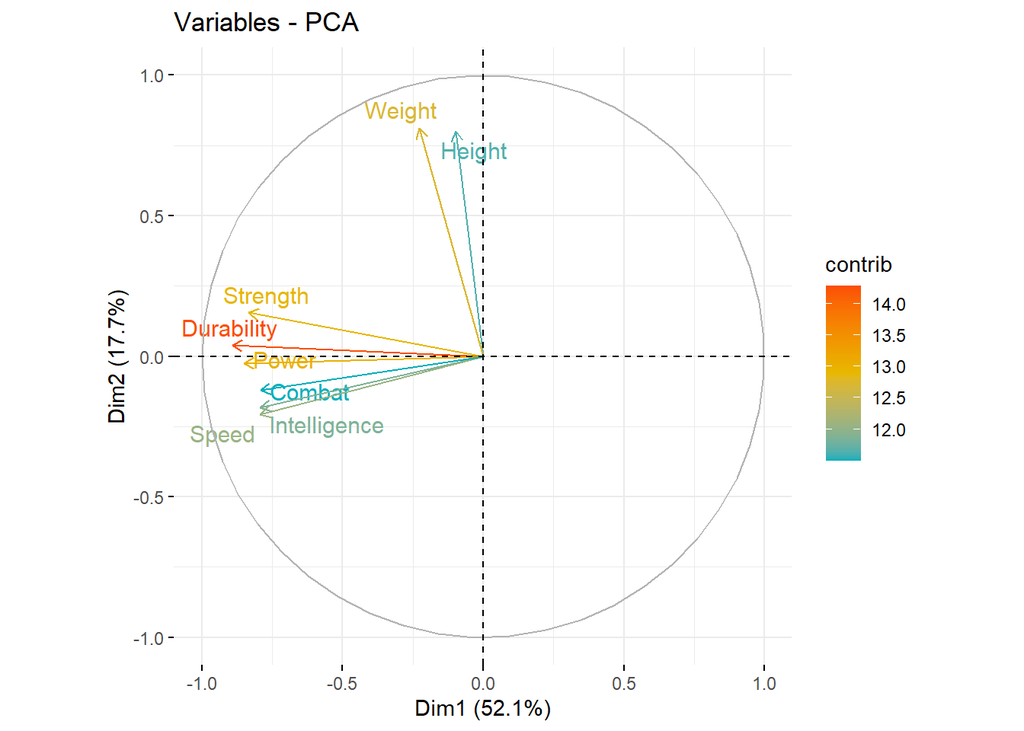

```r
fviz_pca_var(res.pca,
             col.var = "contrib", # Color por contribución al PCA
             gradient.cols = c("#00AFBB", "#E7B800", "#FC4E07"),
             repel = TRUE
             )
```